# Shark Ear Hair

C Mull

2026-06-11

## Shark Ear Hair

This script is for the analysis of ear hair density in 6 innner ear components (lag, sac, utr, mn_pos, mn_ant, and mn_avg) and how it corresponds to hearing sensitivty across a range of frequencies. First the data will be loaded and the response variables (Thr_int, PAL_int) and densities will be standardized (scaled and centered) to allow for comparison across structures.

# Exploratory Plots

Visualize how the chosen thresholds (Thr_int, PAL_int) vary across frequencies and species need to plot threshold over Fr for each species (line plots with error at each frequency). First need summary stats by groupings

```
##   species frequency Thr_int_scale         sd
## 1  Carpet        80    0.51435912 0.05048298
## 2  Carpet       100    0.50821854 0.04248760
## 3  Carpet       150    0.57580515 0.05408848
## 4  Carpet       200    0.61969959 0.04833819
## 5  Carpet       300    0.08399228 1.07896329
## 6  Carpet       450   -1.66285487 0.00000000
```

```
##   species frequency PAL_int_scale         sd
## 1  Carpet        80     0.5201780 0.10818497
## 2  Carpet       100     0.4963321 0.06443258
## 3  Carpet       150     0.5826959 0.07627669
## 4  Carpet       200     0.6524006 0.07031113
## 5  Carpet       300     0.1050228 1.08967000
## 6  Carpet       450    -1.6567597 0.00000000
```

### Thresholds over fequencies by species

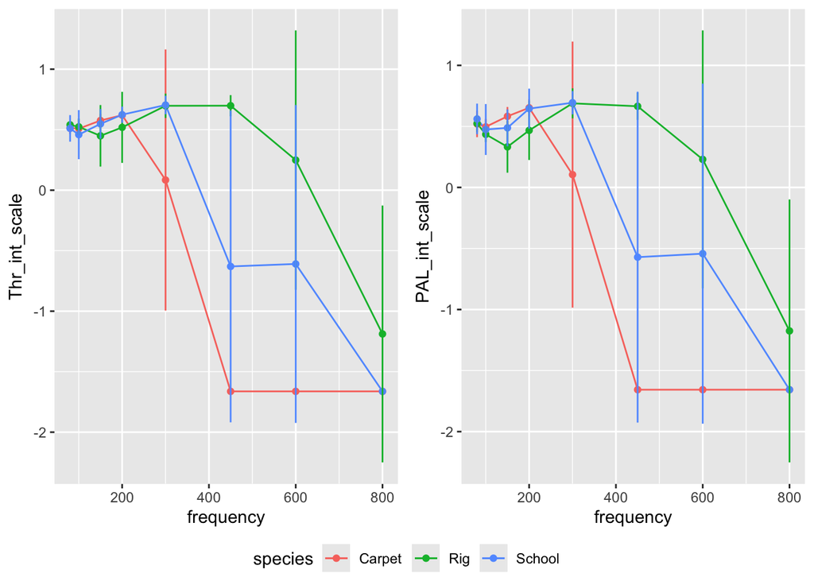

### Densities across inner ear structures by species

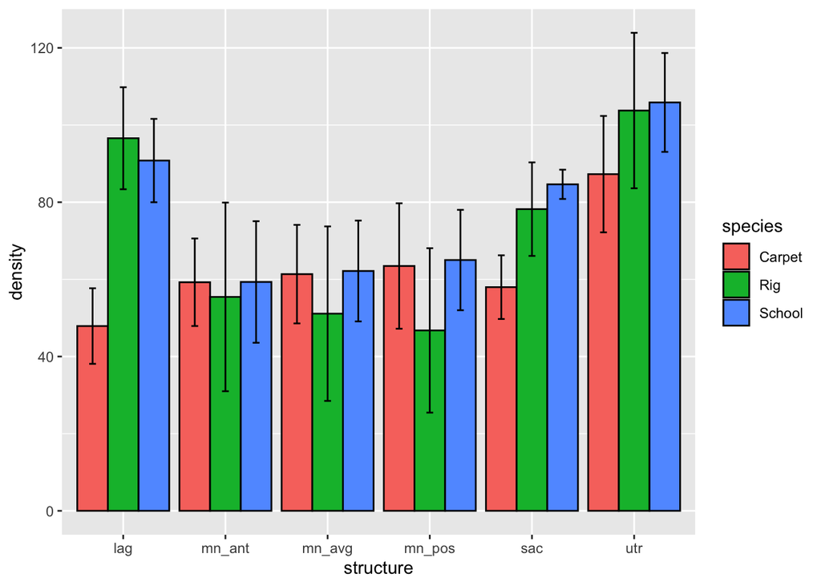

The biggest differences looks to be in the density of hair cells in lag followed by sac and utr.

## Model

Hair cell density predictors across structures are likely correlated, so we also fit separate single-structure models and use LOO-IC to compare their predictive performance.

```
## Divergent transitions (combined model): 0
```

```
##  Family: gaussian
##   Links: mu = identity; sigma = identity
## Formula: PAL_int_scale ~ lag_density_scale + sac_density_scale + utr_density_scale + mn_pos_density_scale + mn_ant_density_scale + mn_avg_density_scale + species + s(frequency, k = 8) + (1 | species:subject)
##    Data: earHair (Number of observations: 136)
##   Draws: 4 chains, each with iter = 10000; warmup = 5000; thin = 1;
##          total post-warmup draws = 20000
##
## Smoothing Spline Hyperparameters:
##                   Estimate Est.Error l-95% CI u-95% CI Rhat Bulk_ESS Tail_ESS
## sds(sfrequency_1)     3.77      1.65     1.67     7.89 1.00     8573    10887
##
## Multilevel Hyperparameters:
## ~species:subject (Number of levels: 17)
##               Estimate Est.Error l-95% CI u-95% CI Rhat Bulk_ESS Tail_ESS
## sd(Intercept)     0.14      0.10     0.01     0.39 1.00     5653     8693
##
## Regression Coefficients:
##                      Estimate Est.Error l-95% CI u-95% CI Rhat Bulk_ESS
## Intercept               -0.45      0.28    -0.98     0.13 1.00     8944
## lag_density_scale        0.17      0.20    -0.22     0.56 1.00    12698
## sac_density_scale       -0.26      0.25    -0.73     0.25 1.00     9936
## utr_density_scale        0.00      0.10    -0.20     0.20 1.00    14722
## mn_pos_density_scale     0.08      0.46    -0.82     0.97 1.00     9155
## mn_ant_density_scale     0.09      0.43    -0.75     0.92 1.00     9048
## mn_avg_density_scale     0.09      0.80    -1.47     1.65 1.00     8912
## speciesRig               0.77      0.44    -0.12     1.60 1.00     9227
## speciesSchool            0.56      0.44    -0.34     1.39 1.00     8951
## sfrequency_1            -0.38      1.01    -2.34     1.59 1.00    25275
##                      Tail_ESS
## Intercept                9501
## lag_density_scale       12151
## sac_density_scale       10259
## utr_density_scale       13489
## mn_pos_density_scale    12817
## mn_ant_density_scale    12426
## mn_avg_density_scale    12451
## speciesRig               9643
## speciesSchool            9687
## sfrequency_1            14380
##
## Further Distributional Parameters:
##       Estimate Est.Error l-95% CI u-95% CI Rhat Bulk_ESS Tail_ESS
## sigma     0.67      0.04     0.59     0.76 1.00    21436    13730
##
## Draws were sampled using sampling(NUTS). For each parameter, Bulk_ESS
## and Tail_ESS are effective sample size measures, and Rhat is the potential
## scale reduction factor on split chains (at convergence, Rhat = 1).
```

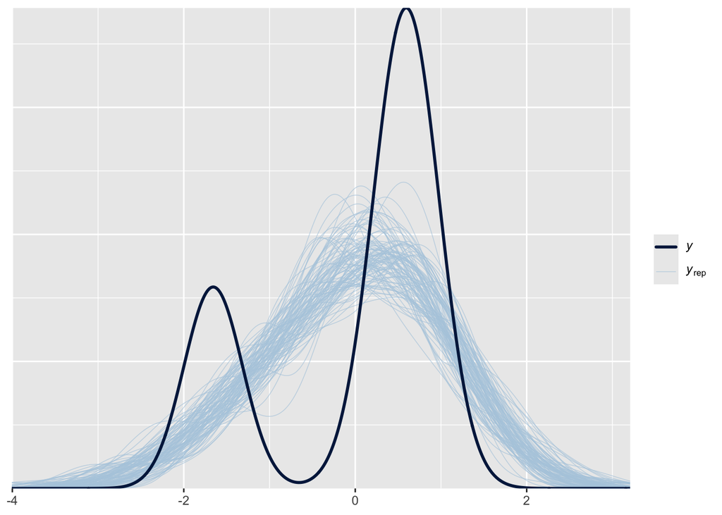

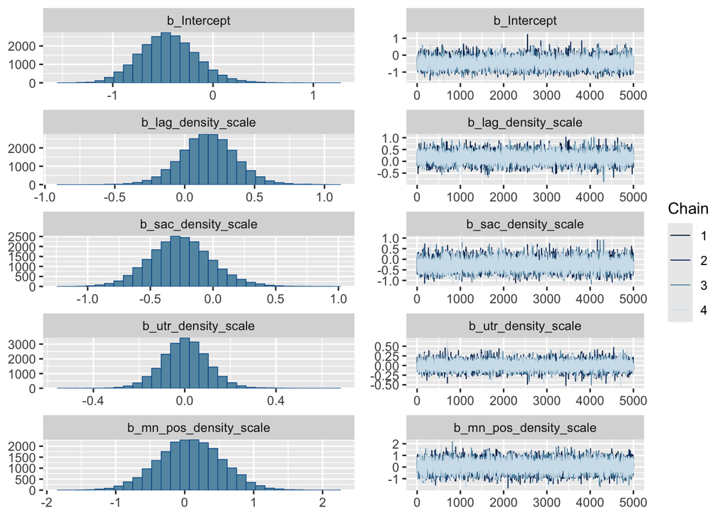

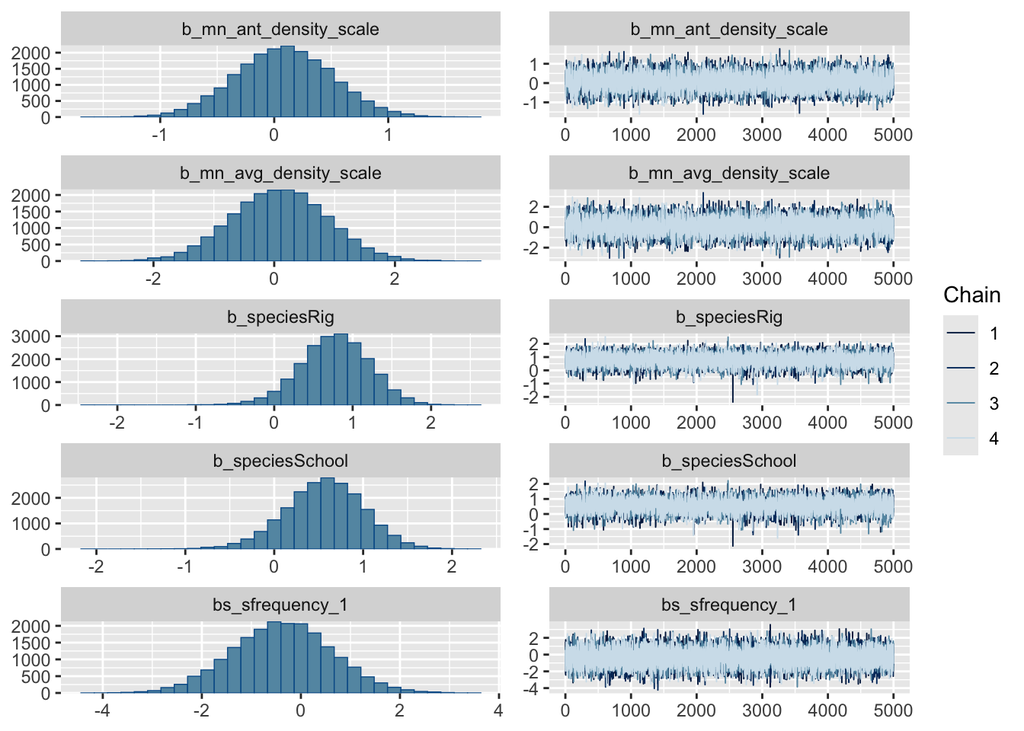

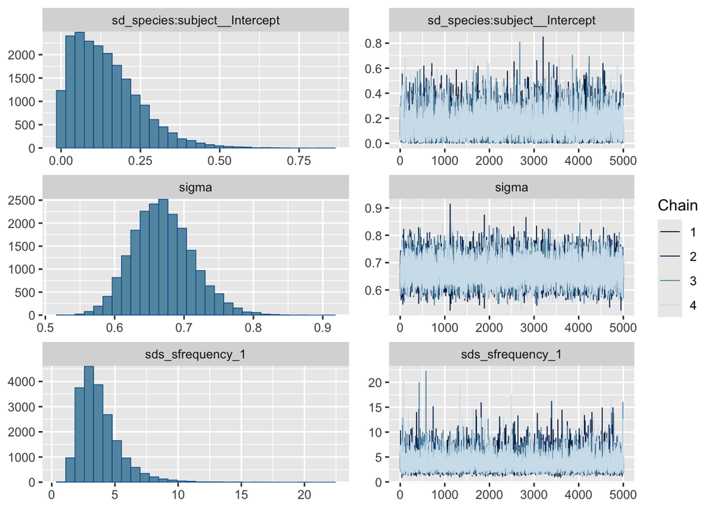

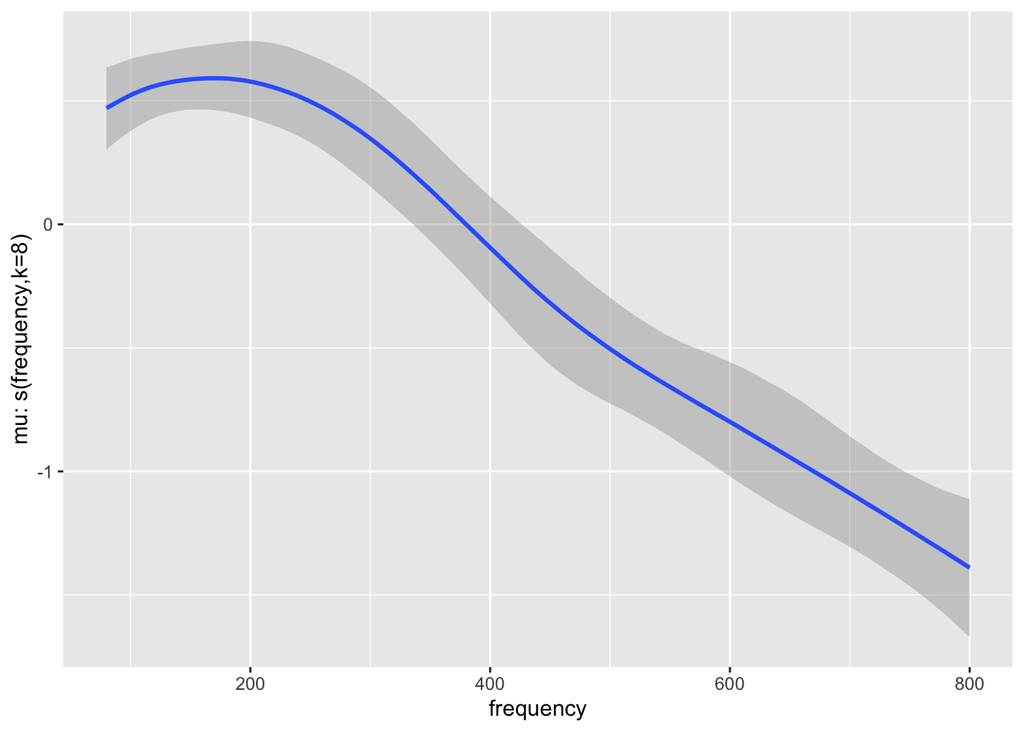

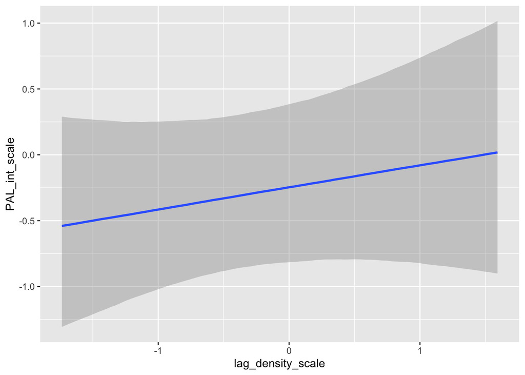

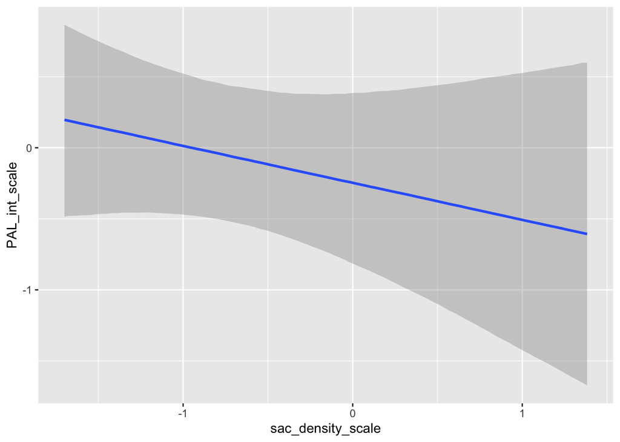

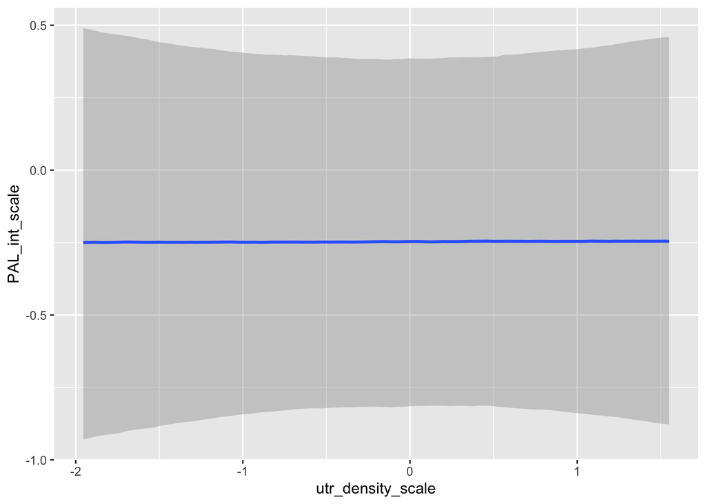

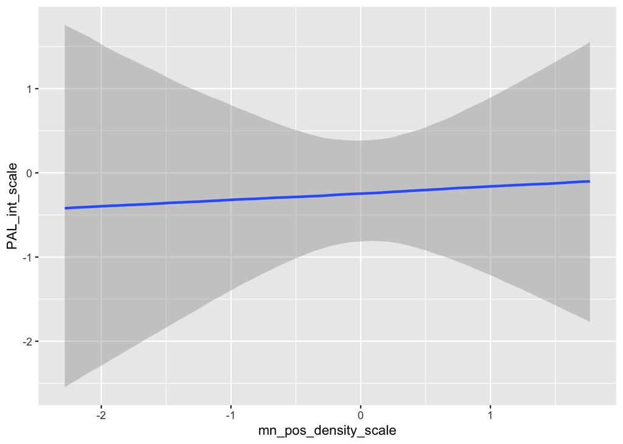

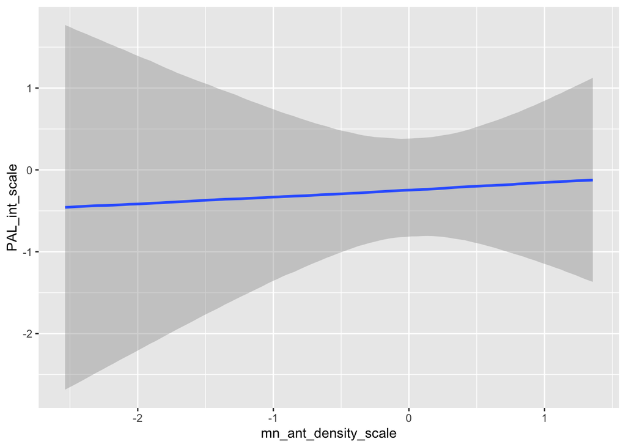

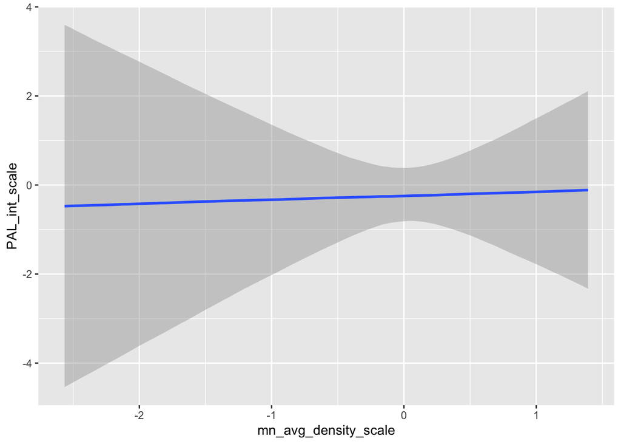

```
##              elpd_diff se_diff
## fit_mn_avg    0.0       0.0
## fit_mn_pos   -0.2       0.5
## fit_mn_ant   -0.3       0.5
## fit_sac      -1.4       0.9
## fit_utr      -1.5       1.5
## fit_lag      -1.6       1.6
## fit_combined -2.3       1.1
```

## Model selection and posterior interpretation

### LOO-IC model comparison

`fit_mn_avg` is taken as the primary model for interpretation, as average macula neglecta density summarises anterior and posterior regions jointly and offers the most parsimonious representation of that structure.

### Posterior distributions — fit_mn_avg

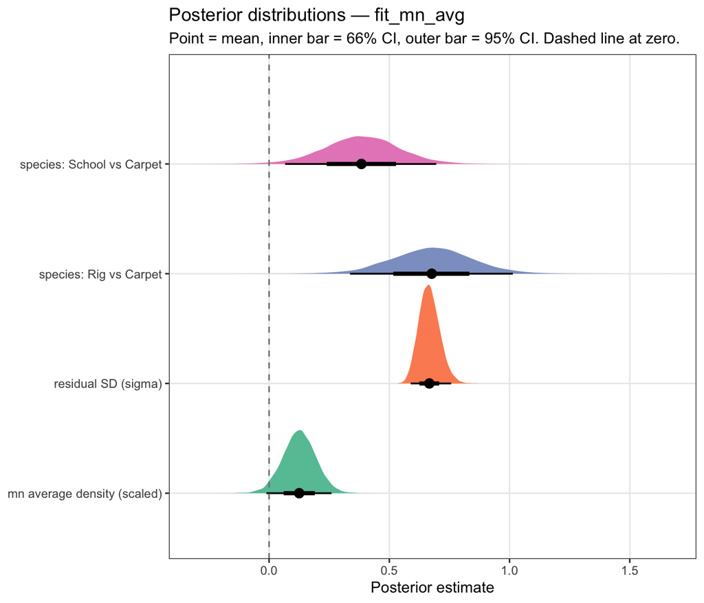

### Interpretation

**Species differences** remain the most clearly supported signals in the model. Rig sharks have credibly higher hearing thresholds than Carpet sharks (the reference level; β ≈ 0.68, 95% CI: 0.34–1.01, P(β > 0) ≈ 99.9%). School sharks show a positive and credible offset (β ≈ 0.38, 95% CI: 0.07–0.70, P(β > 0) ≈ 99%).

**Residual variance** remains substantial (σ ≈ 0.67 on a standardised response), indicating that species identity and macula neglecta density together account for a moderate but incomplete proportion of variation in hearing sensitivity. The frequency spline captures additional structured variance not attributable to hair cell density.

## Species-specific audiograms

The model above assumes a single shared frequency response curve shifted additively per species. The exploratory plots suggest carpet sharks may have a distinct audiogram shape, particularly at higher frequencies. We therefore fit a model with species-specific frequency smooths (`by = species`) to test whether audiogram shape differs across species, and compare it to `fit_mn_avg` via LOO-IC.

```
## Divergent transitions: 0
```

```
##  Family: gaussian
##   Links: mu = identity; sigma = identity
## Formula: PAL_int_scale ~ mn_avg_density_scale + species + s(frequency, by = species, k = 8) + (1 | species:subject)
##    Data: earHair (Number of observations: 136)
##   Draws: 4 chains, each with iter = 10000; warmup = 5000; thin = 1;
##          total post-warmup draws = 20000
##
## Smoothing Spline Hyperparameters:
##                                Estimate Est.Error l-95% CI u-95% CI Rhat
## sds(sfrequencyspeciesCarpet_1)     5.55      2.42     2.48    11.64 1.00
## sds(sfrequencyspeciesRig_1)        3.67      1.72     1.49     7.97 1.00
## sds(sfrequencyspeciesSchool_1)     4.10      1.87     1.76     8.81 1.00
##                                Bulk_ESS Tail_ESS
## sds(sfrequencyspeciesCarpet_1)     7896    10946
## sds(sfrequencyspeciesRig_1)        8830    12163
## sds(sfrequencyspeciesSchool_1)     8979    12704
##
## Multilevel Hyperparameters:
## ~species:subject (Number of levels: 17)
##               Estimate Est.Error l-95% CI u-95% CI Rhat Bulk_ESS Tail_ESS
## sd(Intercept)     0.15      0.09     0.01     0.33 1.00     4715     6459
##
## Regression Coefficients:
##                            Estimate Est.Error l-95% CI u-95% CI Rhat Bulk_ESS
## Intercept                     -0.36      0.11    -0.56    -0.14 1.00    12150
## mn_avg_density_scale           0.13      0.07    -0.01     0.26 1.00    15021
## speciesRig                     0.68      0.16     0.35     1.00 1.00    12540
## speciesSchool                  0.39      0.15     0.09     0.67 1.00    12827
## sfrequency:speciesCarpet_1    -0.02      0.99    -1.95     1.86 1.00    24109
## sfrequency:speciesRig_1       -0.38      0.99    -2.31     1.58 1.00    23696
## sfrequency:speciesSchool_1    -0.34      0.99    -2.28     1.59 1.00    24770
##                            Tail_ESS
## Intercept                     10794
## mn_avg_density_scale          12716
## speciesRig                    11877
## speciesSchool                 12122
## sfrequency:speciesCarpet_1    14462
## sfrequency:speciesRig_1       14960
## sfrequency:speciesSchool_1    14321
##
## Further Distributional Parameters:
##       Estimate Est.Error l-95% CI u-95% CI Rhat Bulk_ESS Tail_ESS
## sigma     0.56      0.04     0.49     0.64 1.00    14911    14605
##
## Draws were sampled using sampling(NUTS). For each parameter, Bulk_ESS
## and Tail_ESS are effective sample size measures, and Rhat is the potential
## scale reduction factor on split chains (at convergence, Rhat = 1).
```

```
##                elpd_diff se_diff
## fit_by_species   0.0       0.0
## fit_mn_avg     -18.0       6.8
```

A ratio of |elpd_diff / se_diff| > 2 indicates the species-specific smooth model is meaningfully better supported. If the ratio is below 2, the shared-curve model (`fit_mn_avg`) is preferred on parsimony grounds.

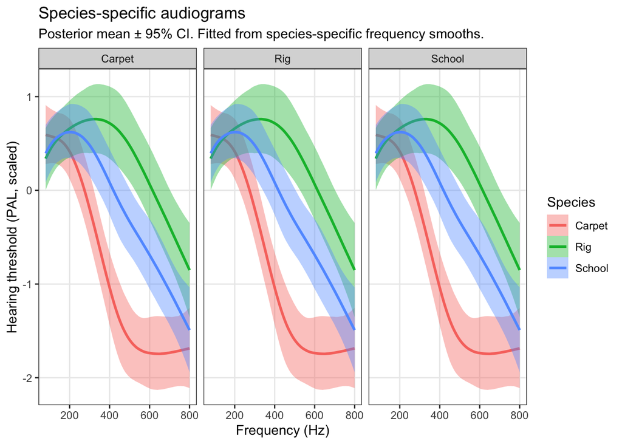

### Compare species senstitivities across frequencies

We will compare the species specific hearing thresholds across the range of frequencies using the estimated marginal means.

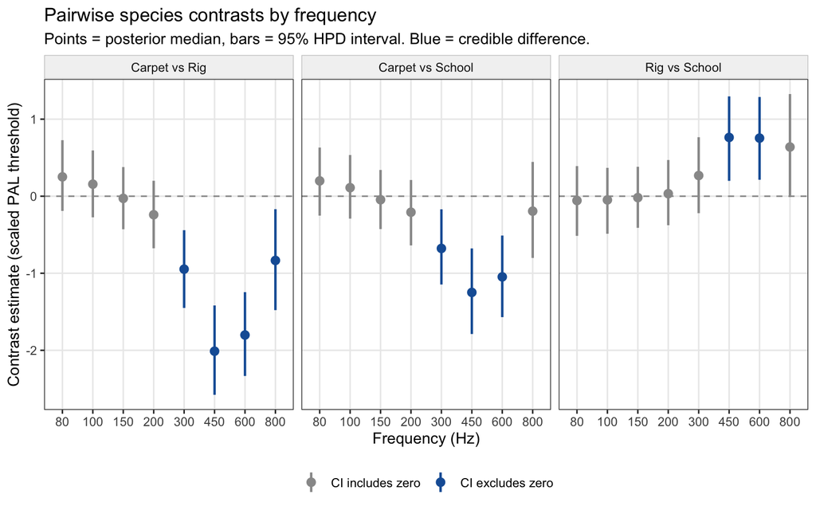

Carpet sharks have less sensitive hearing across the highest frequencies. While Rig has more sensitive hearing than school shark 450 and 600 Hz, and likely 800 Hz with only a small portion of the HPD crossing zero.